# DATA 606 Data Project Proposal

Andrew Bowen

### Setup

```r
library(dplyr)
```

### Data Preparation

```r
# load data
data_url <- "https://raw.githubusercontent.com/fivethirtyeight/data/master/fifa/fifa_countries_audience.csv"

fifa <- read.csv(data_url)
```

### Research question

**You should phrase your research question in a way that matches up with the scope of inference your dataset allows for.** **Research Question**: Is there a stignificant difference in the mean viewership of soccer in Europe vs another continent (confederation)?

### Cases

**What are the cases, and how many are there?** There are viewership data for 191 countries. There are 6 confederations in total. We are interested in comparing the European confederation (UEFA) to the other ones.

### Data collection

**Describe the method of data collection.** This data was collected from FIFA TV viewership during a world cup. It was cleaned and put into csv format by FiveThirtyEight and lives in their [fifa data GitHub repo](https://github.com/fivethirtyeight/data/tree/master/fifa)

### Type of study

**What type of study is this (observational/experiment)?** This is an observational study as the researchers are not actively changing conditions to influence behaviors/outcomes.

### Data Source

**If you collected the data, state self-collected. If not, provide a citation/link.** This data comes from a [FiveThirtyeight data set on FIFA viewership](https://github.com/fivethirtyeight/data/blob/master/fifa/fifa_countries_audience.csv). We’ll focus on the GDP-weighted TV viewership column `gdp_weighted_share`, as that accounts for population differences.

### Independent Variable(s)

Our independent variable is the Confederation (UEFA - Europe, CONCACAF - North America, etc.) to which a country belongs. This is categorical.

### Relevant summary statistics

**Provide summary statistics for each the variables. Also include appropriate visualizations related to your research question (e.g. scatter plot, boxplots, etc). This step requires the use of R, hence a code chunk is provided below. Insert more code chunks as needed.**

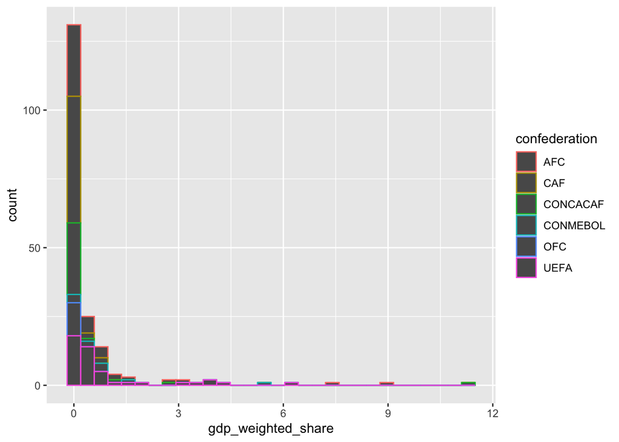

```r
library(ggplot2)

ggplot(fifa, aes(x=gdp_weighted_share, group=confederation, color=confederation)) + geom_histogram()
```

These distributions do not appear normal, so we’ll use the median as our summary stat.

```r
fifa %>%
    group_by(confederation) %>%
    summarise(median_gdp_weighted_share = median(gdp_weighted_share))
```

```
## # A tibble: 6 × 2
##   confederation median_gdp_weighted_share
##   <chr>                             <dbl>
## 1 AFC                                 0.1
## 2 CAF                                 0
## 3 CONCACAF                            0
## 4 CONMEBOL                            0.5
## 5 OFC                                 0
## 6 UEFA                                0.3
```

### Hypothesis Testing

- $H_0$: The mean GDP-weighted viewership share of the world cup in Europe is *not higher* than that of other confederations
- $H_a$: The mean GDP-weighter viewership share of the world cup is *higher* than that of other confederations

Running a t-test between these two groups with a significance level $\alpha = 0.05$

```r
# Filtering into our two groups: Europe vs not Europe.
europe <- fifa %>% filter(confederation == "UEFA")
other_countries <- fifa %>% filter(confederation != "UEFA")

# Running one-tailed t-test using R built-in
t.test(europe$gdp_weighted_share, other_countries$gdp_weighted_share, alternative="greater")
```

```
##
##  Welch Two Sample t-test
##
## data:  europe$gdp_weighted_share and other_countries$gdp_weighted_share
## t = 1.7859, df = 77.677, p-value = 0.03901
## alternative hypothesis: true difference in means is greater than 0
## 95 percent confidence interval:
##  0.02926207        Inf
## sample estimates:
## mean of x mean of y
## 0.8478261 0.4165517
```

Since our p-value is less than our significance level ($\alpha = 0.05$), we can reject the null hypothesis and state that the average weighted viewership of the world cup is higher in Europe than in other confederations.